# Homework 2

```r
library(pacman)
library(gam); data("kyphosis")
require(caTools)
library(glmnet)
library(dplyr)
library(psych)
library(tidyverse)
library(caret)
library(pls)
library(e1071)
library(MASS)
library(klaR)
library(nnet)
library(sigmoid)
library(nnet)
library(fastDummies)
head(kyphosis)
```

|  | Kyphosis | Age | Number | Start |
| --- | --- | --- | --- | --- |
| 1 | absent | 71 | 3 | 5 |
| 2 | absent | 158 | 3 | 14 |
| 3 | present | 128 | 4 | 5 |
| 4 | absent | 2 | 5 | 1 |
| 5 | absent | 1 | 4 | 15 |
| 6 | absent | 1 | 2 | 16 |

#### Q2: Use data set kyphosis from R package “gam”, randomly divide the data into training (75%) and testing (25%) set.

```r
#Splitting Data into Training and Testing Data
set.seed(11)
training.samples <- kyphosis$Kyphosis %>%
  createDataPartition(p = 0.75, list = FALSE)
train.data  <- kyphosis[training.samples, ]
train.data = data.frame(train.data)
test.data <- kyphosis[-training.samples, ]
test.data = data.frame(test.data)


#Proving the proper split
SizeOriginal <- nrow(kyphosis)
SizeTraining <- nrow(train.data)
SizeTest <- nrow(test.data)
PercentageTraining <- (SizeTraining/SizeOriginal)*100
PercentageTest <- (SizeTest/SizeOriginal)*100

sprintf('Percent of Testing Data = %f', PercentageTest)
```

```
[1] "Percent of Testing Data = 24.691358"
```

```r
sprintf('Percent of Training Data = %f', PercentageTraining)
```

```
[1] "Percent of Training Data = 75.308642"
```

#### 2.1 Fit a regularized discriminant analysis model, find the best tuning parameter combination, and evaluate the model using the testing set and report the confusion matrix

```r
set.seed(11)
model.rda <- rda(Kyphosis~.,data=train.data)
grid = trainControl(method = "cv", number = 5)
fit_rda_grid = train(Kyphosis ~ ., data = train.data, method = "rda", trControl = grid)

fit_rda_grid
```

```
Regularized Discriminant Analysis

61 samples
 3 predictor
 2 classes: 'absent', 'present'

No pre-processing
Resampling: Cross-Validated (5 fold)
Summary of sample sizes: 48, 48, 49, 50, 49
Resampling results across tuning parameters:

  gamma  lambda  Accuracy   Kappa
  0.0    0.0     0.8061772   0.22056650
  0.0    0.5     0.8061772   0.27339669
  0.0    1.0     0.8228438   0.34268241
  0.5    0.0     0.8061772   0.17413793
  0.5    0.5     0.7879953   0.00000000
  0.5    1.0     0.7879953   0.00000000
  1.0    0.0     0.7728438   0.12136015
  1.0    0.5     0.7879953   0.00000000
  1.0    1.0     0.7392774  -0.07608696

Accuracy was used to select the optimal model using the largest value.
The final values used for the model were gamma = 0 and lambda = 1.
```

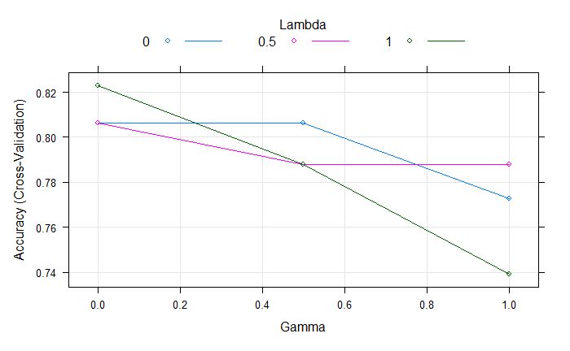

```r
plot(fit_rda_grid)
```

```r
predictions.rda = predict(model.rda, test.data)
confusionM.rda<-confusionMatrix(predictions.rda$class,test.data$Kyphosis)
print(confusionM.rda$table)
```

```
          Reference
Prediction absent present
   absent      16       4
   present      0       0
```

```r
print(confusionM.rda)
```

```
Confusion Matrix and Statistics

          Reference
Prediction absent present
   absent      16       4
   present      0       0

               Accuracy : 0.8
                 95% CI : (0.5634, 0.9427)
    No Information Rate : 0.8
    P-Value [Acc > NIR] : 0.6296

                  Kappa : 0

 Mcnemar's Test P-Value : 0.1336

            Sensitivity : 1.0
            Specificity : 0.0
         Pos Pred Value : 0.8
         Neg Pred Value : NaN
             Prevalence : 0.8
         Detection Rate : 0.8
   Detection Prevalence : 1.0
      Balanced Accuracy : 0.5

       'Positive' Class : absent
```

```r
#Best Tuning Parameters are Gamma and Lambda
```

#### 2.2 Fit a logistic regression model, and interpret the coefficients you estimated

```r
# Fit the model
model.lReg <- nnet::multinom(Kyphosis ~., data = train.data)
predicted.lReg <- model.lReg %>% predict(test.data)
accuracy.lReg <- mean(predicted.lReg == test.data$Kyphosis)
sprintf('Model Accuracy = %f', accuracy.lReg)
```

```
[1] "Model Accuracy = 0.850000"
```

```r
confusionM.lReg<-confusionMatrix(predicted.lReg, test.data$Kyphosis)
print(confusionM.lReg)
```

```
Confusion Matrix and Statistics

          Reference
Prediction absent present
   absent      16       3
   present      0       1

               Accuracy : 0.85
                 95% CI : (0.6211, 0.9679)
    No Information Rate : 0.8
    P-Value [Acc > NIR] : 0.4114

                  Kappa : 0.3478

 Mcnemar's Test P-Value : 0.2482

            Sensitivity : 1.0000
            Specificity : 0.2500
         Pos Pred Value : 0.8421
         Neg Pred Value : 1.0000
             Prevalence : 0.8000
         Detection Rate : 0.8000
   Detection Prevalence : 0.9500
      Balanced Accuracy : 0.6250

       'Positive' Class : absent
```

```r
summary(model.lReg)
```

```
Call:
nnet::multinom(formula = Kyphosis ~ ., data = train.data)

Coefficients:
                  Values   Std. Err.
(Intercept) -2.802845551 1.651499825
Age          0.008487559 0.006541321
Number       0.452436071 0.241935524
Start       -0.116142793 0.077015622

Residual Deviance: 51.44055
AIC: 59.44055
```

```r
# Based off the results,
# Age has little effect to if kyphosis is found in the child,
# Start(which vertebrae the surgeon started on) has a negative correlation,
# Number of operations has a positive correlation to finding the kyphosis.
```

#### 2.3 Fit a regularized logistic regression model, and find the best model from your regularization

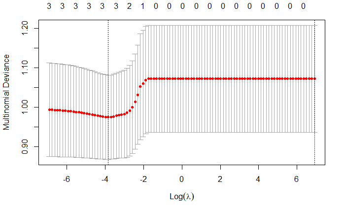

```r
x <- train.data[,2:4] %>% as.matrix()
y <- train.data[,1] %>% as.matrix()

y_dummy <- dummy_columns(y)
colnames(y_dummy)[colnames(y_dummy) == "V_absent"] <- "absent"
colnames(y_dummy)[colnames(y_dummy) == "V_present"] <- "present"


y_dummy1 <- y_dummy[,2:3] %>% as.matrix()

# Perform 10-fold cross-validation to select lambda ---------------------------
lambdas_to_try <- 10^seq(-3, 3, length.out = 100)

# Setting alpha = 1 implements lasso regression
lasso_cv <- cv.glmnet(x, y_dummy1, family="multinomial", alpha = 1, lambda = lambdas_to_try,
                      standardize = TRUE, nfolds = 10)
plot(lasso_cv)
```

```r
lasso_model<-glmnet(x, y_dummy1, family="multinomial", alpha = 1,  lambda=lasso_cv$lambda.min, standardize = TRUE)
test_class_hat<-as.factor(predict(lasso_model, newx = as.matrix(test.data[,2:4]),type="class"))
```

#### 3.1 Use mvrnorm function to generate the training data set below (use seed(100)):

```r
# Training Data
set.seed(100)

cmatrix = cbind(c(1, 0.8),c(0.8, 1.5))
mu = c(0,0)
mu = as.matrix(mu)
mu = t(mu)

cmatrix2 = cbind(c(0.5, 0.4),c(0.4, 1))

mu2 = c(0.5,0.5)
mu2 = as.matrix(mu2)
mu2 = t(mu2)
nrows = 50

x1 = data.frame(mvrnorm(n = 50, mu = mu , Sigma = cmatrix))
x2 = data.frame(mvrnorm(n = 50, mu = mu2, Sigma = cmatrix2))
x_train = rbind(x1,x2)

Y_train = rep(c(1,-1), c(50,50))

Y = as.factor(Y_train)
dat = cbind(x_train, Y)
dat = data.frame(dat)
```

#### 3.2 Fit a nonlinear SVM model (using radial kernel) based on the training data generated in 3.1, and make a plot to visualize the decision boundary (set cost=10).

```r
svmfit = svm(Y ~ ., data = dat, kernel = "radial", cost = 10, scale = FALSE, type = 'C-classification')
print(svmfit)
```

```
Call:
svm(formula = Y ~ ., data = dat, kernel = "radial", cost = 10, type = "C-classification", scale = FALSE)


Parameters:
   SVM-Type:  C-classification
 SVM-Kernel:  radial
       cost:  10

Number of Support Vectors:  68
```

```r
dat.svm<-predict(svmfit,data=dat)


make.grid = function(x_train, n = 100) {
  grange = apply(x_train, 2, range)
  x1 = seq(from = grange[1,1], to = grange[2,1], length = n)
  x2 = seq(from = grange[2,1], to = grange[1,1], length = n)
  expand.grid(X1 = x1, X2 = x2)
}
xgrid = make.grid(x_train)

ygrid = predict(svmfit, xgrid)
plot(xgrid, col = c("black","red")[as.numeric(ygrid)], pch = 20, cex = .2)
points(x_train, col = Y , pch = 19)
```

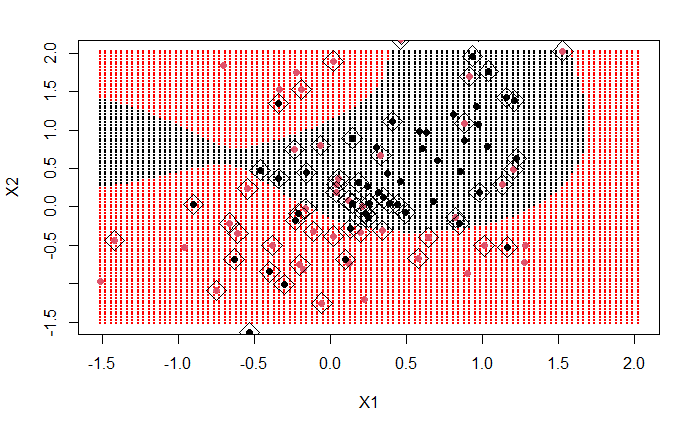

```r
points(x_train[svmfit$index,], pch = 5, cex = 2)
```

```r
# Testing data
set.seed(123)


Sigma = cbind(c(1, 0.8),c(0.8, 1.5))
mu = c(0,0)
mu = as.matrix(mu)
mu = t(mu)

Sigma2 = cbind(c(0.5, 0.4),c(0.4, 1))

mu2 = c(0.5,0.5)
mu2 = as.matrix(mu2)
mu2 = t(mu2)
nrows = 50

x1 = data.frame(mvrnorm(n = 50, mu = mu , Sigma = Sigma))
x2 = data.frame(mvrnorm(n = 50, mu = mu2, Sigma = Sigma2))
x_test = rbind(x1,x2)

Y_test = rep(c(1,-1), c(50,50))

Y_test2 = as.factor(Y_test)
dat.test = cbind(x_test, Y_test2)
dat.test = data.frame(dat.test)

results = predict(svmfit, dat.test)
results = as.factor(results)

ConfusionM.svm<-confusionMatrix(results, dat.test$Y)
print(ConfusionM.svm)
```

```
Confusion Matrix and Statistics

          Reference
Prediction -1  1
        -1 26 22
        1  24 28

               Accuracy : 0.54
                 95% CI : (0.4374, 0.6402)
    No Information Rate : 0.5
    P-Value [Acc > NIR] : 0.2421

                  Kappa : 0.08

 Mcnemar's Test P-Value : 0.8828

            Sensitivity : 0.5200
            Specificity : 0.5600
         Pos Pred Value : 0.5417
         Neg Pred Value : 0.5385
             Prevalence : 0.5000
         Detection Rate : 0.2600
   Detection Prevalence : 0.4800
      Balanced Accuracy : 0.5400

       'Positive' Class : -1
```

#### Read section 11.6 of the textbook “Elements of Statistical Learning”. Follow the steps in the textbook and recreate the Figure 11.6, 11.7, and 11.8 for the Sum of sigmoids only. The objective of this question is helping you better understand the effect of parameter selection on the accuracy of the trained neural network.

```r
# Generating the training data
set.seed(100)
x1_train = data.frame(rnorm(100, mean = 0, sd = 1))
set.seed(101)
x2_train = data.frame(rnorm(100, mean = 0, sd = 1))

x_train = cbind(x1_train,x2_train)
colnames(x_train) = c('x1', 'x2')
x_train2 = matrix(as.numeric(unlist(x_train)),nrow=nrow(x_train))

a1 = c(3,3)
a2 = c(3,-3)

a1 = matrix(a1)
a2 = matrix(a2)

Y_train = sigmoid(x_train2 %*% a1) + sigmoid(x_train2 %*% a2)


# Generating the testing data
set.seed(102)
x1_test = data.frame(rnorm(10000, mean = 0, sd = 1))
set.seed(103)
x2_test = data.frame(rnorm(10000, mean = 0, sd = 1))

x_test = cbind(x1_test,x2_test)
colnames(x_test) = c('x1', 'x2')
x_test2 = matrix(as.numeric(unlist(x_test)),nrow=nrow(x_test))


Y_test = sigmoid(x_test2 %*% a1) + sigmoid(x_test2 %*% a2)
```

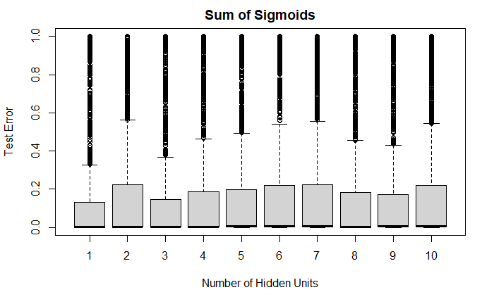

```r
# Developing Neural Network


AvgError = c()
Size = c(1,2,3,4,5,6,7,8,9,10)


# Standard Weight Decay

for (i in seq(Size)){
  ran.nn <- nnet(x_train, Y_train, size = i, rang = 0.1, decay = .005, maxit = 200)
  predic = predict(ran.nn, x_test2)
  TestError = (Y_test - predic)^2
  AvgError = c(AvgError,TestError)
}
AvgError2 = c()
Size = c(1,2,3,4,5,6,7,8,9,10)

# No Weight Decay

for (i in seq(Size)){
  ran.nn <- nnet(x_train, Y_train, size = i, rang = 0.1, decay = 0, maxit = 200)
  predic = predict(ran.nn, x_test2)
  TestError = (Y_test - predic)^2
  AvgError2 = c(AvgError2,TestError)
}
AvgError3 = c()
Size = c(1,2,3,4,5,6,7,8,9,10)

# Large Weight Decay

for (i in Size){
  ran.nn <- nnet(x_train, Y_train, size = i, rang = 0.1, decay = .1, maxit = 200)
  predic = predict(ran.nn, x_test2)
  TestError = (Y_test - predic)^2
  AvgError3 = c(AvgError3,TestError)
}
AvgError4 = c()
Weights = c(.00,.01,.02,.03,.04,.05,.06,.07,.08,.09,.10,.11,.12,.13,.14,.15)

# Changing Weights

for (i in Weights){
  ran.nn <- nnet(x_train, Y_train, size = 10, rang = 0.1, decay = i, maxit = 200)
  predic = predict(ran.nn, x_test2)
  TestError = (Y_test - predic)^2
  AvgError4 = c(AvgError4,TestError)
}
# Making the Box plots

Size = data.frame(Size)
Weights = data.frame(Weights)
Error1 = data.frame(AvgError)
Error2 = data.frame(AvgError2)
Error3 = data.frame(AvgError3)
Error4 = data.frame(AvgError4)

Error1 = cbind.data.frame(Size, Error1)
Error2 = cbind.data.frame(Size, Error2)
Error3 = cbind.data.frame(Size, Error3)
Error4 = cbind.data.frame(Weights, Error4)



boxplot(AvgError~Size, data = Error1, main = "Sum of Sigmoids", xlab = "Number of Hidden Units", ylab = "Test Error")
```

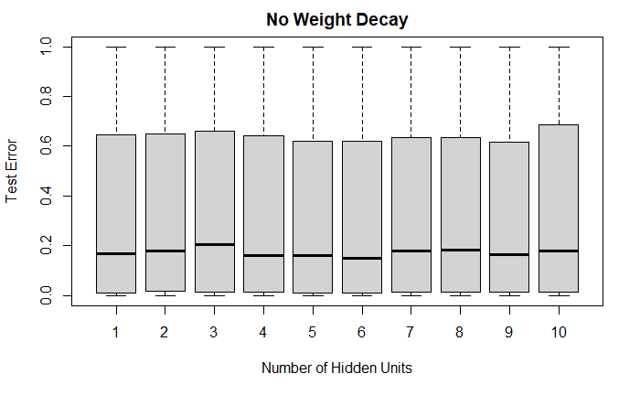

```r
boxplot(AvgError2~Size, data = Error2, main = "No Weight Decay", xlab = "Number of Hidden Units", ylab = "Test Error")
```

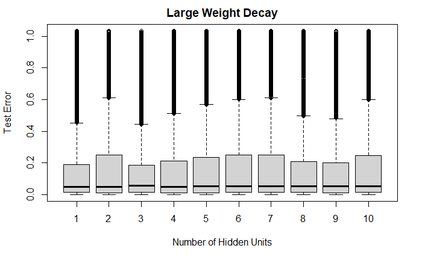

```r
boxplot(AvgError3~Size, data = Error3, main = "Large Weight Decay", xlab = "Number of Hidden Units", ylab = "Test Error")
```

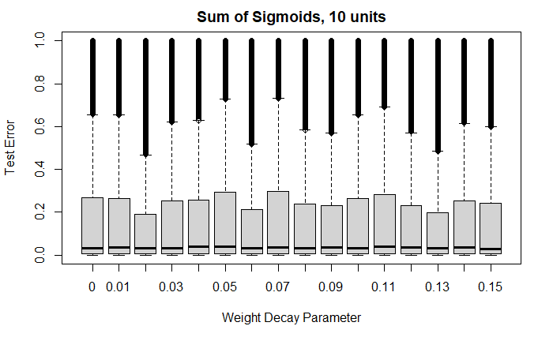

```r
boxplot(AvgError4~Weights, data = Error4, main = "Sum of Sigmoids, 10 units", xlab = "Weight Decay Parameter", ylab = "Test Error")
```